# GO_category_summary

Laura Biggins

22/08/2019

```r
library("devtools")
load_all()
library(tidyverse)
library(DT)
library(RColorBrewer)
library(gridExtra)
library(formattable)
```

## GO category summary

where was the list of genes obtained from? I think this was a gtf file of all the genes in the genome, but how many of these were in the GO categories? How many annotations does each gene have? This is getting in to territory that has been explored elsewhere.

I think we want to establish which of our results can identify biases in the data rather than just general rubbish.

I generated completely random lists of genes and ran these through the same gene ontology analysis. Two gene sets out of 200 returned any results at all.

Could it be that the genes that have interesting properties, like length, location, high number of transcripts stand out from the rest so get studied more, get annotated more and therefore generate more significant GO results?

Hopefully this is the case for some, and then for some, we can actually use these categories to identify biases.

```r
#suspect_cats <- read_tsv("../data/suspect_categories.txt")
suspect_cats <- read_tsv("../data/suspect_categories_archive.txt")

suspect_cats %>%
  count(bias_source) %>%
  arrange(desc(n))
```

| bias_source | n |
| --- | --- |
| high_transcripts | 1206 |
| long | 996 |
| public_data | 489 |
| vv_high_transcripts | 466 |
| very_long | 274 |
| very_high_transcripts | 270 |
| closest_genes | 134 |
| chrMT | 132 |
| chr19 | 128 |
| chr12 | 69 |

[output cut: 13 more lines]

```r
suspect_cats %>%
  count(GO_ID) %>%
  count(n)
```

| n | nn |
| --- | --- |
| 1 | 1075 |
| 2 | 719 |
| 3 | 328 |
| 4 | 117 |
| 5 | 43 |
| 6 | 15 |
| 7 | 9 |
| 8 | 1 |

```r
get_IDs_in_category <- function(category){

    filter(suspect_cats, bias_source == category) %>%
      pull(GO_ID)
}

all_bias_categories <- suspect_cats %>%
  distinct(bias_source) %>%
  pull(bias_source)

get_count_for_cat <- function(category){
  suspect_cats %>%
  filter(GO_ID %in% get_IDs_in_category(category)) %>%
  count(GO_ID) %>%
  count(n)
}
```

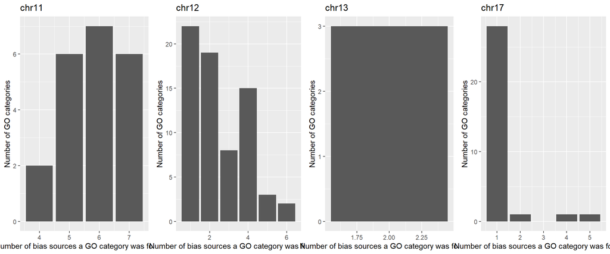

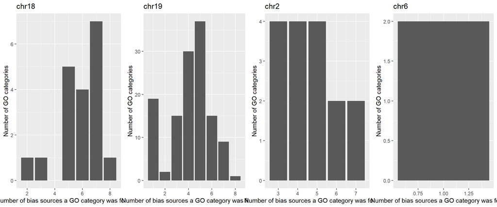

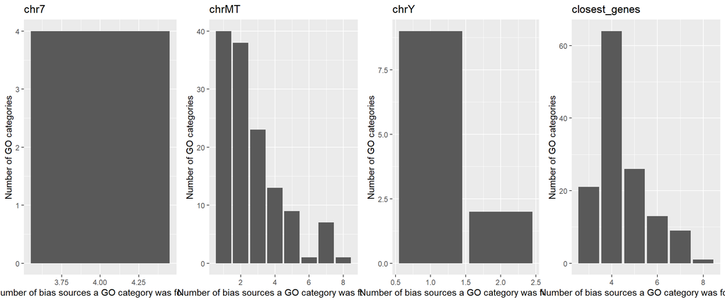

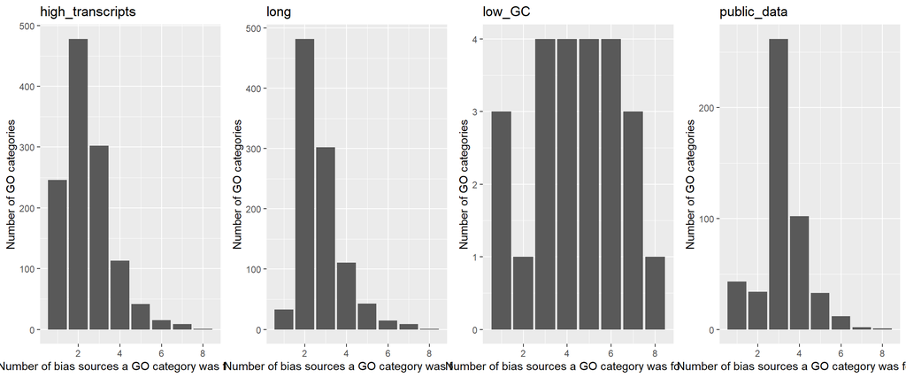

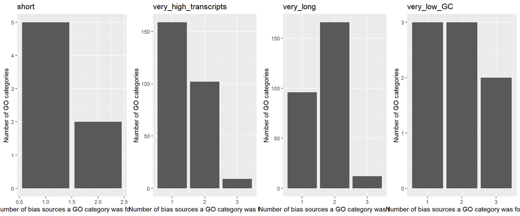

```r
plot_category_counts <- function(category){

  get_count_for_cat(category) %>%
    ggplot(aes(x = n, y = nn)) +
    geom_bar(stat = "identity") +
    ggtitle(category) +
    xlab("Number of bias sources a GO category was found in") +
    ylab("Number of GO categories")
}
p <- lapply(all_bias_categories, plot_category_counts)

for (i in seq(0, to = 16, by = 4)){
  grid.arrange(p[[1+i]], p[[2+i]], p[[3+i]], p[[4+i]], ncol = 4)
}
```

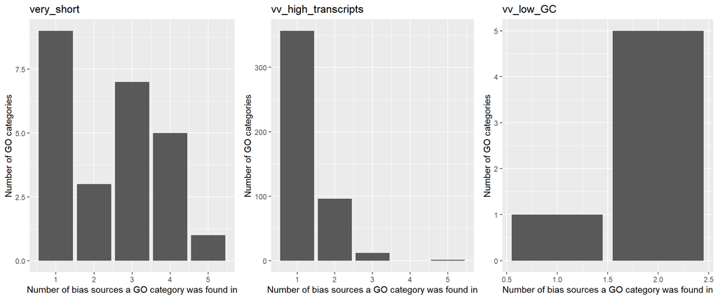

```r
grid.arrange(p[[21]], p[[22]], p[[23]], ncol = 3)
```

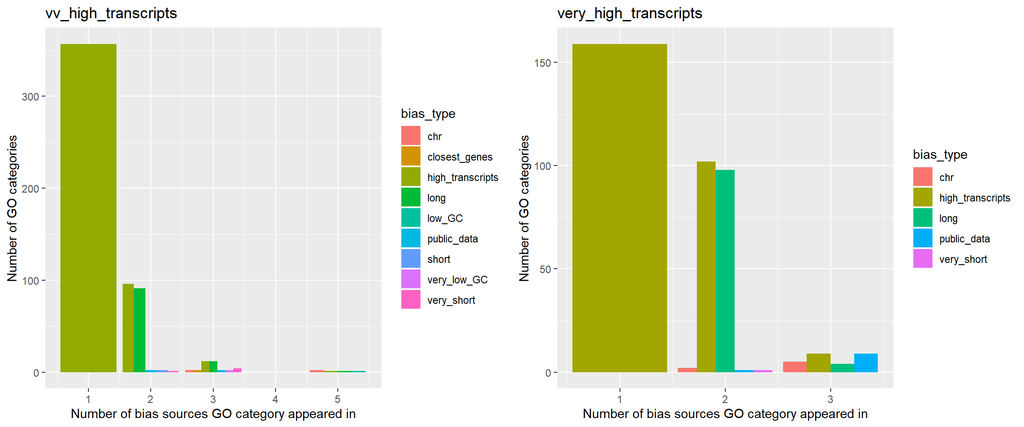

```r
# Have a bias_type column that is almost the same as bias_source, but groups some of the categories together so that if some categories are found in 2 datasets - eg. long and high transcripts, and long and very high transcripts, and long and vv high transcripts, this is just shown as long and high transcripts.
# This is an attempt to simplify the plots
suspect_cats <- suspect_cats %>%
  mutate(bias_type = if_else(grepl("chr", bias_source), "chr", bias_source)) %>%
  mutate(bias_type = str_replace_all(bias_type, "very_high_transcripts", "high_transcripts")) %>%
  mutate(bias_type = str_replace_all(bias_type, "vv_high_transcripts", "high_transcripts")) %>%
  mutate(bias_type = str_replace_all(bias_type, "very_long", "long"))

plot_more_detail <- function(category){
  suspect_cats %>%
    filter(GO_ID %in% get_IDs_in_category(category)) %>%
    count(GO_ID) %>%
    left_join(suspect_cats) %>%
    arrange(desc(n)) %>%
    group_by(n) %>%
    count(bias_type) %>%
    ggplot(aes(x = n, y = nn, fill = bias_type)) +
      geom_bar(stat = "identity", position = "dodge") +
      ggtitle(category) +
      xlab("Number of bias sources GO category appeared in") +
      ylab("Number of GO categories")
}

p <- lapply(all_bias_categories, plot_more_detail)
names(p) <- all_bias_categories

grid.arrange(p[["vv_high_transcripts"]], p[["very_high_transcripts"]], ncol = 2)
```

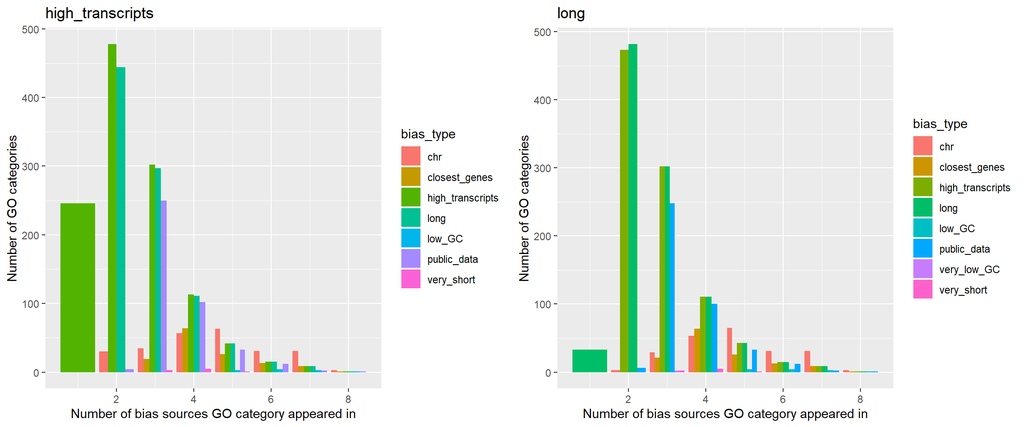

```r
grid.arrange(p[["high_transcripts"]], p[["long"]], ncol = 2)
```

```r
get_count_for_occurrence <- function(category, occurrences){
    suspect_cats %>%
    filter(GO_ID %in% get_IDs_in_category(category)) %>%
    count(GO_ID) %>%
    left_join(suspect_cats) %>%
    arrange(desc(n)) %>%
    group_by(n) %>%
    count(bias_type) %>%
    filter(n==occurrences) %>%
    pull(nn) %>%
    first()
}
```

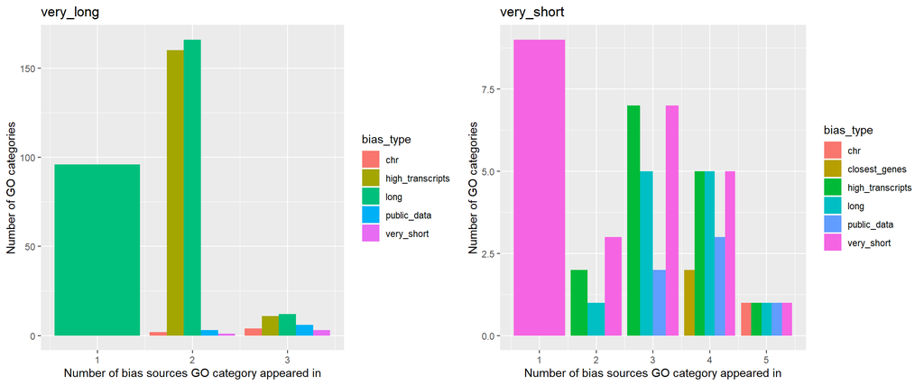

```r
grid.arrange(p[["very_long"]], p[["very_short"]], ncol = 2)
```

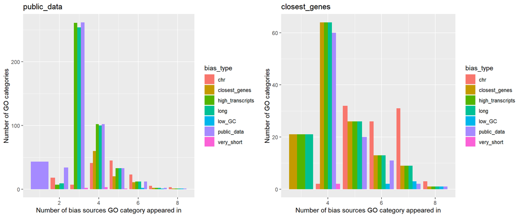

```r
grid.arrange(p[["public_data"]], p[["closest_genes"]], ncol = 2)
```

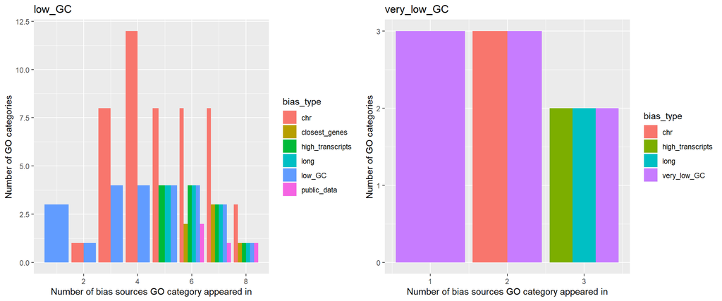

```r
grid.arrange(p[["low_GC"]], p[["very_low_GC"]], ncol = 2)
```

The GC and chr plots make more sense when the categories are divided in to separate chromosomes.

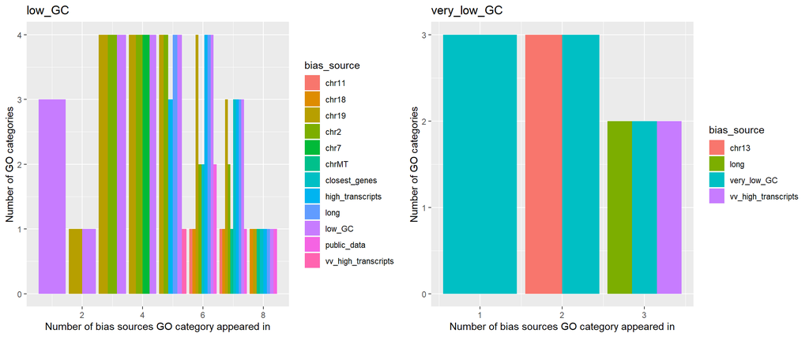

```r
plot_more_detail <- function(category){
  suspect_cats %>%
    filter(GO_ID %in% get_IDs_in_category(category)) %>%
    count(GO_ID) %>%
    left_join(suspect_cats) %>%
    arrange(desc(n)) %>%
    group_by(n) %>%
    count(bias_source) %>%
    ggplot(aes(x = n, y = nn, fill = bias_source)) +
      geom_bar(stat = "identity", position = "dodge") +
      ggtitle(category) +
      xlab("Number of bias sources GO category appeared in") +
      ylab("Number of GO categories")
}

p <- lapply(all_bias_categories, plot_more_detail)
names(p) <- all_bias_categories

grid.arrange(p[["low_GC"]], p[["very_low_GC"]], ncol = 2)
```

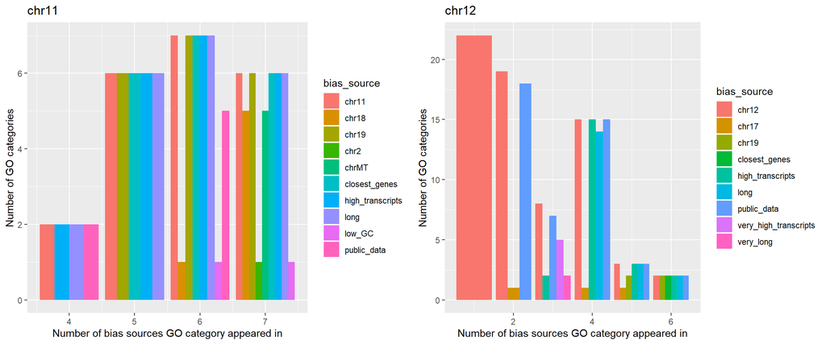

```r
grid.arrange(p[["chr11"]], p[["chr12"]], ncol = 2)
```

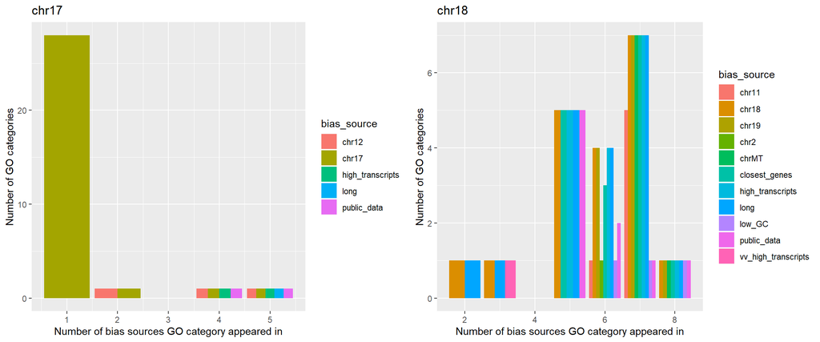

```r
grid.arrange(p[["chr17"]], p[["chr18"]], ncol = 2)
```

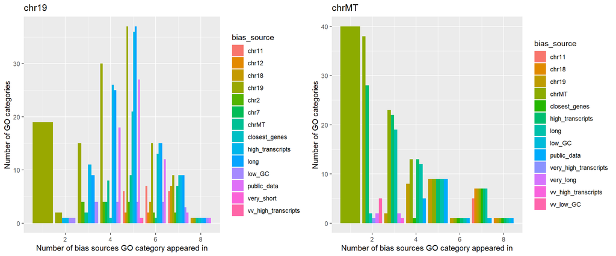

```r
grid.arrange(p[["chr19"]], p[["chrMT"]], ncol = 2)
```

I’m artificially inflating the number of GO categories by displaying it like this, as for 2+ sources, the bars show at least twice the number of GO catgories. Can we show them side by side?

**I’d like to look at how many categories a gene is annotated with, as I think that might affect this.**